# Reproducible Research: Peer Assessment 1

## Loading and preprocessing the data

```r
data <- read.csv(unz("activity.zip", "activity.csv"))
library(tidyr)
library(dplyr)
```

```r
library(ggplot2)
library(ggpubr)
```

## What is mean total number of steps taken per day?

The missing values in the dataset are ignored using the command na.rm=TRUE.  
Total number of steps taken per day:

```r
total_steps <- data%>% group_by(date) %>% summarise(total_steps = sum(steps, na.rm = TRUE))
```

Histogram of the total number of steps taken each day:

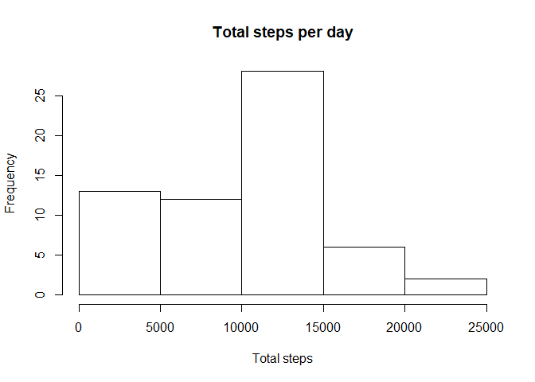

```r
hist(total_steps$total_steps, xlab = "Total steps", main = "Total steps per day" )
```

```r
mean_steps <- data%>% group_by(date) %>% summarise(mean_steps = mean(steps, na.rm = TRUE))
median_steps <- data%>% group_by(date) %>% summarise(median_steps = median(steps, na.rm = TRUE))
mean_steps
```

```
## # A tibble: 61 x 2
##    date       mean_steps
##    <fct>           <dbl>
##  1 2012-10-01    NaN
##  2 2012-10-02      0.438
##  3 2012-10-03     39.4
##  4 2012-10-04     42.1
##  5 2012-10-05     46.2
##  6 2012-10-06     53.5
##  7 2012-10-07     38.2
##  8 2012-10-08    NaN
##  9 2012-10-09     44.5
## 10 2012-10-10     34.4
## # ... with 51 more rows
```

```r
median_steps
```

```
## # A tibble: 61 x 2
##    date       median_steps
##    <fct>             <dbl>
##  1 2012-10-01           NA
##  2 2012-10-02            0
##  3 2012-10-03            0
##  4 2012-10-04            0
##  5 2012-10-05            0
##  6 2012-10-06            0
##  7 2012-10-07            0
##  8 2012-10-08           NA
##  9 2012-10-09            0
## 10 2012-10-10            0
## # ... with 51 more rows
```

```r
mean(mean_steps$mean_steps, na.rm = TRUE)
```

```
## [1] 37.3826
```

```r
median(median_steps$median_steps, na.rm = TRUE)
```

```
## [1] 0
```

## What is the average daily activity pattern?

Calculation of the average number of steps per 5-minute interval:

```r
interval_avg <- data%>% group_by(interval) %>% summarise(avg_steps = mean(steps, na.rm = TRUE))
```

Time series plot of the 5-minute interval (x-axis) and the average number of steps averaged across all days (y-axis):

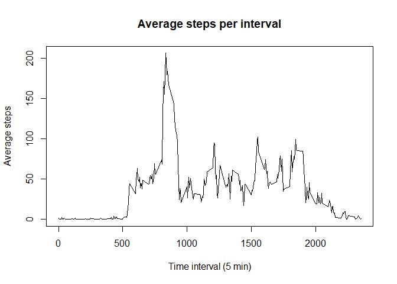

```r
plot(interval_avg$interval, interval_avg$avg_steps, type = "l", xlab = "Time interval (5 min)", ylab = "Average steps", main ="Average steps per interval")
```

Which 5-minute interval, on average across all the days in the dataset, contains the maximum number of steps?:

```r
max_steps_interval <- interval_avg[which.max(interval_avg$avg_steps), ]
max_steps_interval$interval
```

```
## [1] 835
```

## Imputing missing values

```r
number_Nas <- sum(is.na(data$steps))
percentage_Nas <- mean(is.na(data$steps))
```

The strategy for filling in all of the missing values in the dataset consists in using the mean for that 5-minute interval:

```r
new_data <- merge(data, interval_avg, by = "interval", x.all = TRUE)
new_data$steps[is.na(new_data$steps)] <- new_data$avg_steps[is.na(new_data$steps)]
new_df <- new_data %>% select(-avg_steps) %>% arrange(date, interval)
```

New dataset that is equal to the original dataset but with the missing data filled in:

```r
total_steps_new <- new_df%>% group_by(date) %>% summarise(total_steps = sum(steps, na.rm = TRUE))
```

Histogram of the total number of steps taken each day:

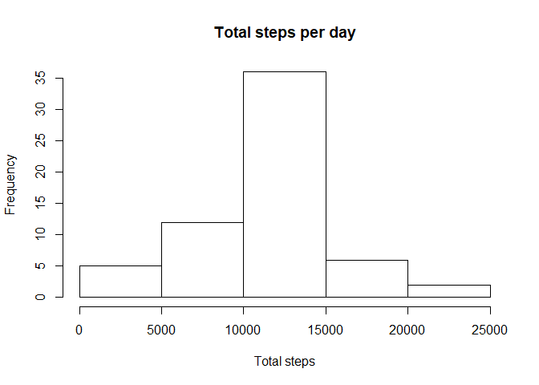

```r
hist(total_steps_new$total_steps, xlab = "Total steps", main = "Total steps per day" )
```

```r
mean_steps_new <- new_df%>% group_by(date) %>% summarise(mean_steps = mean(steps, na.rm = TRUE))
median_steps_new <- new_df%>% group_by(date) %>% summarise(median_steps = median(steps, na.rm = TRUE))
mean_steps_new
```

```
## # A tibble: 61 x 2
##    date       mean_steps
##    <fct>           <dbl>
##  1 2012-10-01     37.4
##  2 2012-10-02      0.438
##  3 2012-10-03     39.4
##  4 2012-10-04     42.1
##  5 2012-10-05     46.2
##  6 2012-10-06     53.5
##  7 2012-10-07     38.2
##  8 2012-10-08     37.4
##  9 2012-10-09     44.5
## 10 2012-10-10     34.4
## # ... with 51 more rows
```

```r
median_steps_new
```

```
## # A tibble: 61 x 2
##    date       median_steps
##    <fct>             <dbl>
##  1 2012-10-01         34.1
##  2 2012-10-02          0
##  3 2012-10-03          0
##  4 2012-10-04          0
##  5 2012-10-05          0
##  6 2012-10-06          0
##  7 2012-10-07          0
##  8 2012-10-08         34.1
##  9 2012-10-09          0
## 10 2012-10-10          0
## # ... with 51 more rows
```

```r
mean(mean_steps_new$mean_steps, na.rm = TRUE)
```

```
## [1] 37.3826
```

```r
median(median_steps_new$median_steps, na.rm = TRUE)
```

```
## [1] 0
```

## Are there differences in activity patterns between weekdays and weekends?

The dataset used is the one with the filled missing values.  
New factor variable in the dataset with two levels – “weekday” and “weekend” indicating whether a given date is a weekday or weekend day.

```r
weekend <- c("Saturday", "Sunday")
new_df$days <- factor((weekdays(as.Date(new_df$date)) %in% weekend), labels = c("weekday", "weekend"))
interval_avg_new <- new_df%>% group_by(interval, days) %>% summarise(avg_steps = mean(steps, na.rm = TRUE))
```

Panel plot containing a time series plot of the 5-minute interval and the average number of steps taken, averaged across all weekday days or weekend days:

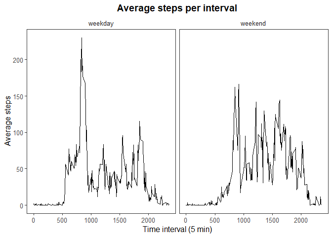

```r
plot_new_data <- ggplot(interval_avg_new, aes(interval_avg_new$interval, interval_avg_new$avg_steps)) +
  geom_line() +
  ggtitle("Average steps per interval") +
  xlab("Time interval (5 min)") + ylab("Average steps")
my_plot <- plot_new_data + facet_grid(. ~ days)+ theme_bw()+theme(text = element_text(size=12),panel.grid.major = element_blank(),panel.grid.minor =element_blank(),strip.background = element_blank(),plot.title = element_text(hjust=0.5))+  font("title", size = 14, face = "bold")
print(my_plot)
```